# Estimable Functions and Contrasts in R

## Disclaimer

This is an update on the synthesis and derivation notebook of the two previous years. After the lecture, we start with the development of new material. The new material is only based on group means and contrasts of group means.

## Data

We are using the dataset on body weight and breed.

```r
s_bw_breed_path <- here::here("docs", "data", "asm_bw_breed.csv")
tbl_bw_breed <- readr::read_delim(s_bw_breed_path, delim = ",")
tbl_bw_breed
```

| Animal | Body Weight | Breed |
| --- | --- | --- |
| 1 | 471 | Angus |
| 2 | 463 | Angus |
| 4 | 470 | Angus |
| 7 | 518 | Limousin |
| 8 | 511 | Limousin |
| 9 | 510 | Limousin |
| 10 | 541 | Limousin |
| 3 | 481 | Simmental |
| 5 | 496 | Simmental |
| 6 | 491 | Simmental |

## Regression on Dummy Variables

Let us assume that we are interested in the difference between body weights of animals of the breed `Limousin` compared to the body weight of animals of breed `Angus`. This difference can be visualized by the following plot

```r
# filter data
library(dplyr)
tbl_bw_an_li <- tbl_bw_breed %>%
  filter(Breed != "Simmental")
tbl_bw_an_li
```

| Animal | Body Weight | Breed |
| --- | --- | --- |
| 1 | 471 | Angus |
| 2 | 463 | Angus |
| 4 | 470 | Angus |
| 7 | 518 | Limousin |
| 8 | 511 | Limousin |
| 9 | 510 | Limousin |
| 10 | 541 | Limousin |

Show the plot

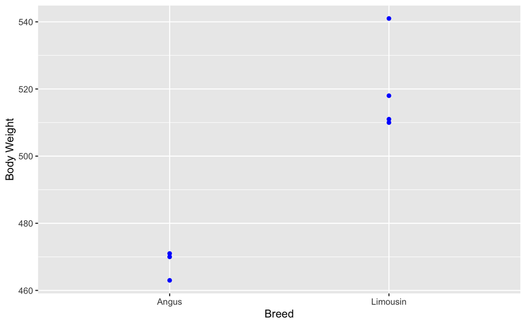

```r
library(ggplot2)
plot_bw_diff_li_an <- ggplot(tbl_bw_an_li, aes(x = Breed, y = `Body Weight`)) +
  geom_point(color = "blue")
plot_bw_diff_li_an
```

The difference of mean body weight between animals of the two breeds can be shown by fitting a regression of body weight on a breed code where Angus animals are assigned the code $0$ and animals of breed Limousin are assigned the code $1$.

```r
tbl_bw_an_li$BreedCodeLi <- as.numeric(as.factor(tbl_bw_an_li$Breed)) - 1
tbl_bw_an_li
```

| Animal | Body Weight | Breed | BreedCodeLi |
| --- | --- | --- | --- |
| 1 | 471 | Angus | 0 |
| 2 | 463 | Angus | 0 |
| 4 | 470 | Angus | 0 |
| 7 | 518 | Limousin | 1 |
| 8 | 511 | Limousin | 1 |
| 9 | 510 | Limousin | 1 |
| 10 | 541 | Limousin | 1 |

The regression of `Body Weight` on `BreedCode` is

```r
lm_bw_brc_li <- lm(`Body Weight` ~ BreedCodeLi, data = tbl_bw_an_li)
(smry_bw_brc_li <- summary(lm_bw_brc_li))
```

```
Call:
lm(formula = `Body Weight` ~ BreedCodeLi, data = tbl_bw_an_li)

Residuals:
  1   2   3   4   5   6   7
  3  -5   2  -2  -9 -10  21

Coefficients:
            Estimate Std. Error t value Pr(>|t|)
(Intercept)  468.000      6.653  70.341  1.1e-08 ***
BreedCodeLi   52.000      8.802   5.908  0.00198 **
---
Signif. codes:  0 ‘***’ 0.001 ‘**’ 0.01 ‘*’ 0.05 ‘.’ 0.1 ‘ ’ 1

Residual standard error: 11.52 on 5 degrees of freedom
Multiple R-squared:  0.8747,    Adjusted R-squared:  0.8496
F-statistic: 34.91 on 1 and 5 DF,  p-value: 0.001978
```

Adding the resuting regression line to the above plot leads to

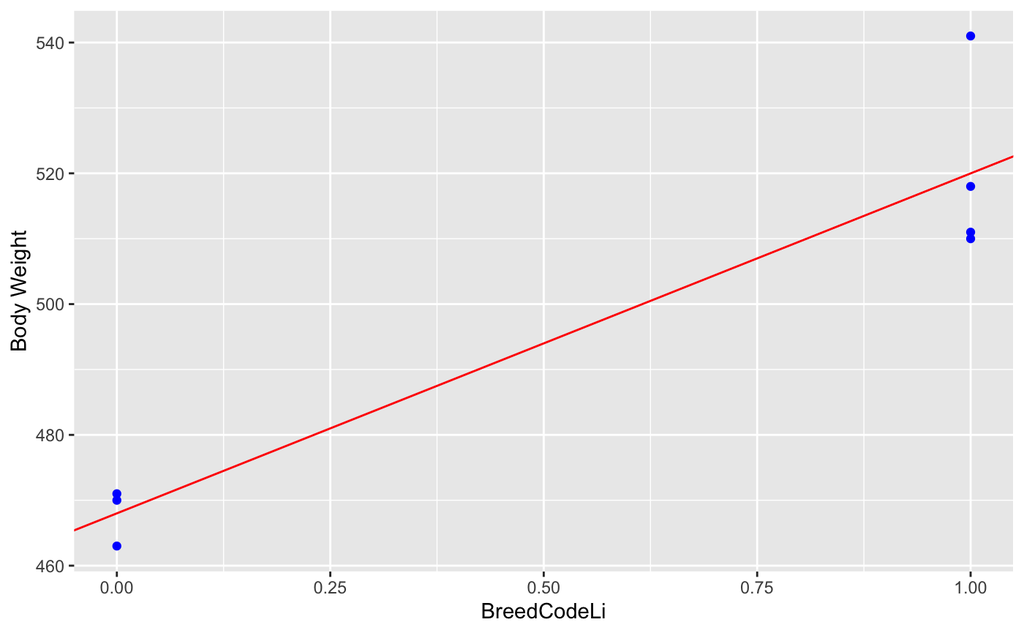

```r
plot_bw_brc_li_an <- ggplot(tbl_bw_an_li, aes(x = BreedCodeLi, y = `Body Weight`)) +
  geom_point(color = "blue") +
  geom_abline(intercept = smry_bw_brc_li$coefficients["(Intercept)", "Estimate"],
              slope = smry_bw_brc_li$coefficients["BreedCodeLi", "Estimate"],
              color = "red")
plot_bw_brc_li_an
```

The intersection of the red regression line with $x=0$ on the one hand shows the intercept of the regression line and on the other hand corresponds to the mean Angus body weight

## Old Stuff Below Here

The material from 2024 and before was mostly based on explaining parameter estimates via estimable functions of solutions of least squares normal equations. While this is possible and can work, it adds un-necessary complexity. For documentation, the previously used material is left in here.

## References

[1] Notebooks on contrasts from previous years [2] Material from https://bookdown.org/pingapang9/linear_models_bookdown/chap-contrasts.html

## Data

The data set used is the one on a synthetic observation and on breeds of animals.

```r
s_data_path <- here::here("docs", "data", "est_fun_breed_data.csv")
tbl_est_fun <- readr::read_delim(s_data_path, delim = ",")
tbl_est_fun
```

| Animal | Breed | Observation |
| --- | --- | --- |
| 1 | Angus | 16 |
| 2 | Angus | 10 |
| 3 | Angus | 19 |
| 4 | Simmental | 11 |
| 5 | Simmental | 13 |
| 6 | Limousin | 27 |

Use a second dataset with body weight and breed

```r
s_bw_breed_path <- here::here("docs", "data", "asm_bw_breed.csv")
tbl_bw_breed <- readr::read_delim(s_bw_breed_path, delim = ",")
tbl_bw_breed
```

| Animal | Body Weight | Breed |
| --- | --- | --- |
| 1 | 471 | Angus |
| 2 | 463 | Angus |
| 4 | 470 | Angus |
| 7 | 518 | Limousin |
| 8 | 511 | Limousin |
| 9 | 510 | Limousin |
| 10 | 541 | Limousin |
| 3 | 481 | Simmental |
| 5 | 496 | Simmental |
| 6 | 491 | Simmental |

## Use Regression To Describe Group Means

Start by looking only at breeds Angus and Limousin in the dataset on body weight. Then use the dummy coding where Angus animals receive a value of $0$ and Limousin animals receive a code of $1$. The regression of body weight on that dummy coding results in a regression line that goes through the mean body weights for both breeds. That means, we get

```r
library(dplyr)
tbl_bw_breed <- tbl_bw_breed %>%
  filter(Breed != "Simmental")
tbl_bw_breed$BreedFactor <- as.numeric(as.factor(tbl_bw_breed$Breed))-1
tbl_bw_breed
```

| Animal | Body Weight | Breed | BreedFactor |
| --- | --- | --- | --- |
| 1 | 471 | Angus | 0 |
| 2 | 463 | Angus | 0 |
| 4 | 470 | Angus | 0 |
| 7 | 518 | Limousin | 1 |
| 8 | 511 | Limousin | 1 |
| 9 | 510 | Limousin | 1 |
| 10 | 541 | Limousin | 1 |

Fit regression

```r
lm_bw_breed <- lm(`Body Weight` ~ BreedFactor, data = tbl_bw_breed)
(smry_bw_breed <- summary(lm_bw_breed))
```

```
Call:
lm(formula = `Body Weight` ~ BreedFactor, data = tbl_bw_breed)

Residuals:
  1   2   3   4   5   6   7
  3  -5   2  -2  -9 -10  21

Coefficients:
            Estimate Std. Error t value Pr(>|t|)
(Intercept)  468.000      6.653  70.341  1.1e-08 ***
BreedFactor   52.000      8.802   5.908  0.00198 **
---
Signif. codes:  0 ‘***’ 0.001 ‘**’ 0.01 ‘*’ 0.05 ‘.’ 0.1 ‘ ’ 1

Residual standard error: 11.52 on 5 degrees of freedom
Multiple R-squared:  0.8747,    Adjusted R-squared:  0.8496
F-statistic: 34.91 on 1 and 5 DF,  p-value: 0.001978
```

Create a plot

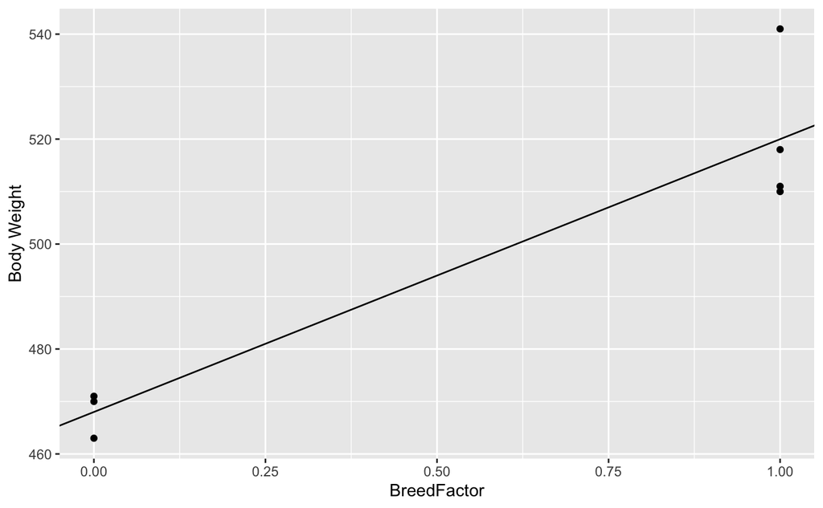

```r
library(ggplot2)
pl_bw_breed <- ggplot(tbl_bw_breed, aes(x = BreedFactor, y = `Body Weight`)) +
  geom_point() +
  geom_abline(slope = smry_bw_breed$coefficients["BreedFactor", "Estimate"],
              intercept = smry_bw_breed$coefficients["(Intercept)", "Estimate"])
pl_bw_breed
```

The intersection of the regression line at the two values $0$ and $1$ for BreedFactor are at the mean value for body weight for the two breeds AN and LI. The writing the parameter vector $b$ as

$$b = \left[ \begin{array}{c} b_0 \\ b_1
\end{array}\right]$$

We see in the next section how to express $b$ as contrasts of group means $M_{AN}$ and $M_{LI}$.

## Idea of Contrasts

According to chapter 7 of [2], contrasts can be explained as follows.

A **contrast** is a linear combination of parameters or statistics. An alternative term for “linear combination” is **weighted sum**. We are currently focusing on statistics from two levels of a given factor. In our dataset this corresponds to two levels of the factor breed. As an example, we have a look at the observation for Simmental and for Angus animals.

Let $M_{AN}$ be the mean observation for all animals of breed Angus and $M_{SI}$ be the mean observation for all Simmental animals. The sum of the two means can be written as

$$L_1 = M_{AN} + M_{SI}
= \left[\begin{array}{cc} 1 & 1 \end{array}\right] \cdot \left[
\begin{array}{c} M_{AN} \\ M_{SI} \end{array}\right]
= l_1^T \cdot m$$

A different contrast ($L_2$) insepects the difference between the two means.

$$L_2 = M_{AN} - M_{SI}
= \left[\begin{array}{cc} 1 & -1 \end{array}\right] \cdot \left[
\begin{array}{c} M_{AN} \\ M_{SI} \end{array}\right]
= l_2^T \cdot m$$

These contrasts $l_1$ and $l_2$ can be combined into a matrix $L$

$$L = \left[\begin{array}{cc} l_1 &
l_2 \end{array} \right]$$

Then we can write the above two contrasts as

$$L^T \cdot m$$

As seen in the previous section, the estimate of the parameter vector $b$ can be written as contrasts of group means and as a consequence, the group means can be written as a function of parameter estimates

$$m = \left[ \begin{array}{c} M_{AN}
\\ M_{SI} \end{array}\right]
= \left[ \begin{array}{c} \widehat{b_0} \\ \widehat{b_0} +
\widehat{b_1} \end{array}\right]
= \left[\begin{array}{cc} 1 & 0 \\ 1 & 1 \end{array}\right]
\cdot \left[ \begin{array}{c} \widehat{b_0}
\\ \widehat{b_1} \end{array}\right]
= L^T \cdot \widehat{b}$$

$$\widehat{b} = (L^T)^{-1} \cdot
m$$

As shown below, the matrix $L^T$ is used to determine what type of contrasts are used in R.

## Contrasts in R

For a given dataset, the contrast matrix can be obtained as a result of the function `contrasts()`. For our original example with three breeds this yields in

```r
tbl_bw_breed <- readr::read_delim(s_bw_breed_path, delim = ",")
mat_ctr_br <- contrasts(as.factor(tbl_bw_breed$Breed))
mat_ctr_br
```

[output not shown]

```r
mat_mod_br <- model.matrix(`Body Weight` ~ Breed, tbl_bw_breed)
mat_mod_br
```

Adding a column representing the intercept to the contrasts matrix and taking its inverse, results in the matrix of estimable functions

```r
mat_ctr_br_ext <- cbind(matrix(rep(1, nrow(mat_ctr_br))), mat_ctr_br)
colnames(mat_ctr_br_ext)[1] <- "(Intercept)"
mat_ctr_br_ext
```

Then the inverse

```r
mat_est_fun <- solve(mat_ctr_br_ext)
mat_est_fun
```

[output not shown]

The first row indicates which group mean is used for the intercept. The remaining rows represent the estimable functions used for the effect with the corresponding row name.

## Validation

The results on the investigated connection between contrasts and estimable functions is validated with our example dataset. For this validation, we first need a set of solutions to the least squares normal equations. As the first step, we set up the design matrix $\mathbf{X}$ and use it to compute the crossproduct $\mathbf{X}^T\mathbf{X}$

```r
#tbl_flem_bw_breed
mat_X <- model.matrix(`Body Weight` ~ 0 + Breed, tbl_bw_breed)
mat_X <- cbind(matrix(1, nrow = nrow(tbl_bw_breed), ncol = 1), mat_X)
dimnames(mat_X) <- NULL
mat_xtx <- crossprod(mat_X)
mat_xtx
```

The solution to the normal equations are obtained by

```r
vec_y <- tbl_bw_breed$`Body Weight`
mat_xty <- crossprod(mat_X, vec_y)
mat_xtx_ginv <- MASS::ginv(mat_xtx)
mat_b_sol <- crossprod(t(mat_xtx_ginv), mat_xty)
mat_b_sol
```

The intercept in the treatment contrasts are computed as the mean observations for the first factor level. For the factor `Breed` this corresponds to the mean of all animals of breed `Angus`. This is verified by

```r
library(dplyr)
mean((tbl_bw_breed %>% filter(Breed == "Angus"))$`Body Weight`)
```

Based on the matrix of estimable functions, the effect assigned to the `BreedLimousin` corresponds to the difference between the third and the second component of the solution vector

```r
mat_b_sol[3] - mat_b_sol[2]
```

The effect assigned to `BreedSimmental` is the difference between the last and the second component of the solution vector

```r
mat_b_sol[4] - mat_b_sol[2]
```

These effects can also be found in the summary output of the `lm` -object.

```r
lm_bw_br <- lm(`Body Weight` ~ Breed, data = tbl_bw_breed)
(smry_lm_bw_br <- summary(lm_bw_br))
```

[output not shown]

## Vector of Group Means

The vector $m$ is the vector of group means

```r
n_mean_AN <- mean((tbl_bw_breed %>% filter(Breed == "Angus"))$`Body Weight`)
n_mean_LI <- mean((tbl_bw_breed %>% filter(Breed == "Limousin"))$`Body Weight`)
n_mean_SI <- mean((tbl_bw_breed %>% filter(Breed == "Simmental"))$`Body Weight`)
(vec_group_mean <- c(n_mean_AN, n_mean_LI, n_mean_SI))
```

Pre-multiplication of the vector of group means with the matrix of estimable functions yields

```r
crossprod(t(mat_est_fun), vec_group_mean)
```

```
                 [,1]
(Intercept) 468.00000
Limousin     52.00000
Simmental    21.33333
```